# Introduction to RNAseq Analysis: Part One

# Overview

The next generation sequencing (NGS) data in this example was obtained from NCBI GEO and the Sequence Read Archive (SRA). This notebook is not intended to show you how to do these steps yourself. Attempting such a project requires at least a moderate level of experience with computing in Unix/Linux. However, we will provide at least a brief overview of each step so that you understand how NGS data is handled. Importantly, there are always new developments in tools and algorithms to analyze NGS data, so the pipeline shown here is only one of many possible pipelines.

Here are the steps that we will cover in this Notebook:

1. Accessing SRA data.
2. QC of reads pre-trimming with **FastQC**.
3. Quality trimming of sequence reads with **Trimmomatic**.
4. QC of reads post-trimming with **FastQC**.
5. Sequence read alignment with **STAR**.
6. Overview of BAM file format.
7. Generating gene count matrix.

**Please note that most preprocessing analyses and tools used in this notebook need to be run in bash shell. The programming language is denoted at the beginning of the code cell using either `%use bash` or `%use r`.**

# Examining data on SRA

We will use bulk RNA-Seq data of prostate cancer patients from this study: [Yun, et al., Oncotarget., 2017](https://www.ncbi.nlm.nih.gov/pmc/articles/PMC5777737/). Bulk RNA-seq data was obtained from primary-site samples from patients with prostate cancer(PC) at various stages of progression, namely, benign prostate hyperplasia (BPH), localized PC, AdvPC(advanced prostate cancer), and CRPC(castration-resistant prostate cancer). The data was deposited to NCBI GEO as GSE80609.

Information of raw seqencing data and samples is available in the [Sequence Read Archive](https://www.ncbi.nlm.nih.gov/sra?term=SRP073789). From the [Sequence Read Archive](https://www.ncbi.nlm.nih.gov/sra?term=SRP073789) page, click 'Send results to Run selector' to open the SRA Run selector page. (See picture below.)

[figure not shown]

SRA Run selector stores all the runs/samples of the study in a clean table. We usually use Run selector to determine which runs/samples should be included in the analysis. The page of Run selector looks like this:

[figure not shown]

The Run selector page has three sections:

- **Common Fields**: contains basic information about the data.
- **Select**: shows sequence file information of the selected runs. You can download the metadata (which is the table we will use in the next section) or Accession List (which only contains the Run ID in the first column of the table) for selected runs.
- **Found 45 Items**: summarizes the information for all runs including data size, treatment groups and data type.

In this data, there are a total of 45 runs and 92.03Gb data. We won't use all 45 runs in our analysis due to the large data size. We will only select a subset of runs from each category of 'progression_step'.

From the table, you can access the complete SRA information and raw data for an experiment of each sample by clicking on its Run ID [SRR3437043](https://trace.ncbi.nlm.nih.gov/Traces/index.html?view=run_browser&acc=SRR3437043&display=metadata). You will find additional details about this specific sample and the parent experiment.(See picture below.)

[figure not shown]

You can download raw sequencing data by clicking the "Data Access" tab, but we will show you how to download raw data easily using bash.

Now, let's go back to the SRA Run selector page using the browser's back button.

**Important: For demonstrating the anlysis in this notebook, we only selected a subset of 8 samples among the total 45 samples, with 2 samples in each of the 4 groups.**

In this tutorial, we selected 8 runs from the total 45 runs to use as an example and save running time. There are 4 categories in the "progression_step" column--BPH, CaP, advanced CaP and CRPC. (For details about each condition, please check the reference paper.) We selected 2 samples from each of the four categories. The Run ID of the selected samples are: SRR3437043, SRR3437044 (for BPH); SRR3437051, SRR3437052 (for CaP); SRR3437053, SRR3437060 (for advanced CaP); SRR3437054, SRR3437056 (for CRPC).

We need the Metadata table of these 8 runs for later analysis. The Metadata table was already downloaded by us in "./data/SraRunTable.txt". But we will show you how to access this table if you want to use a different set of samples. To download the Metadata table, you need to first select the samples you need using the checkbox in the "Found 45 Items" section. After selection, click the toggle button "Selected" in the above "Select" section, then the list will be filtered to only include your selected samples. After double-checking that the sample selection is correct, you can click the "Metadata" button on the right to download the table for selected samples only. If you want to download metadata for all samples, use the "Metadata" button in the first row with row name of "Total". The downloaded Metadata file is names as "SraRunTable.txt".

[figure not shown]

We will take a look at the metadata table of the 8 samples in R.

```python
%use r
# check metadata using R
run_table <- read.delim("./data/SraRunTable.txt", as.is=TRUE, sep=",")
run_table
```

A data.frame: 8 × 28

| Run <chr> | Assay.Type <chr> | AvgSpotLen <int> | BioProject <chr> | biopsy_site <chr> | BioSample <chr> | Center.Name <chr> | Consent <chr> | DATASTORE.filetype <chr> | DATASTORE.provider <chr> | ⋯ | MBytes <int> | normal.tumor <chr> | Organism <chr> | Platform <chr> | progression_step <chr> | ReleaseDate <chr> | sample_acc <chr> | Sample.Name <chr> | source_name <chr> | SRA.Study <chr> |
| --- | --- | --- | --- | --- | --- | --- | --- | --- | --- | --- | --- | --- | --- | --- | --- | --- | --- | --- | --- | --- |
| SRR3437043 | RNA-Seq | 202 | PRJNA319483 | prostate | SAMN04893323 | GEO | public | sra | ncbi | ⋯ | 1609 | nomal | Homo sapiens | ILLUMINA | BPH | 2018-04-23T00:00:00Z | SRS1410395 | GSM2131564 | BPH | SRP073789 |
| SRR3437044 | RNA-Seq | 202 | PRJNA319483 | prostate | SAMN04893324 | GEO | public | sra | gs,ncbi,s3 | ⋯ | 1519 | nomal | Homo sapiens | ILLUMINA | BPH | 2018-04-23T00:00:00Z | SRS1410393 | GSM2131565 | BPH | SRP073789 |
| SRR3437051 | RNA-Seq | 202 | PRJNA319483 | prostate | SAMN04893331 | GEO | public | sra | ncbi | ⋯ | 1748 | tumor | Homo sapiens | ILLUMINA | CaP | 2018-04-23T00:00:00Z | SRS1410400 | GSM2131572 | CaP | SRP073789 |
| SRR3437052 | RNA-Seq | 202 | PRJNA319483 | prostate | SAMN04893332 | GEO | public | sra | ncbi | ⋯ | 1974 | tumor | Homo sapiens | ILLUMINA | CaP | 2018-04-23T00:00:00Z | SRS1410402 | GSM2131573 | CaP | SRP073789 |
| SRR3437053 | RNA-Seq | 202 | PRJNA319483 | prostate | SAMN04893333 | GEO | public | sra | ncbi | ⋯ | 1607 | tumor | Homo sapiens | ILLUMINA | advanced CaP | 2018-04-23T00:00:00Z | SRS1410403 | GSM2131574 | advanced CaP | SRP073789 |
| SRR3437054 | RNA-Seq | 202 | PRJNA319483 | prostate | SAMN04893334 | GEO | public | sra | gs,ncbi,s3 | ⋯ | 1616 | tumor | Homo sapiens | ILLUMINA | CRPC | 2018-04-23T00:00:00Z | SRS1410404 | GSM2131575 | CRPC | SRP073789 |
| SRR3437056 | RNA-Seq | 202 | PRJNA319483 | prostate | SAMN04893336 | GEO | public | sra | ncbi | ⋯ | 1519 | tumor | Homo sapiens | ILLUMINA | CRPC | 2018-04-23T00:00:00Z | SRS1410406 | GSM2131577 | CRPC | SRP073789 |
| SRR3437060 | RNA-Seq | 202 | PRJNA319483 | prostate | SAMN04893340 | GEO | public | sra | ncbi | ⋯ | 1093 | tumor | Homo sapiens | ILLUMINA | advanced CaP | 2018-04-23T00:00:00Z | SRS1410410 | GSM2131581 | advanced CaP | SRP073789 |

**Important: For the following pipeline, we only provided example codes for processing one of the samples. But the count matrix at the last section uses all 8 samples.**

## Download SRA Data

SRA maintains the [sratoolkit](https://www.ncbi.nlm.nih.gov/books/NBK158900/), a collection of tools to download and convert SRA data. Generally, you want the unaligned sequence reads in FASTQ format. However, SRA does not simply have these files ready for simple transfer. Rather, sequence reads are stored at SRA in a format that must be converted to FASTQ. This can be a slow process depending on the size of the files. Considering the data size, we only subset 8 samples among the total 45 samples to perform the analysis.

One special note is that `module load` is used solely for some of the university servers to load pre-installed softwares. `module load` is not valid for use on your own computer. If you would like to run any softwares used in this workshop on your own computer, you will have to install the softwares (e.g. sratoolkit) to your PC first. For `sratoolkit`, you can install it by following the instructions [here](https://github.com/ncbi/sra-tools/wiki/01.-Downloading-SRA-Toolkit). Then, you will source the `fastq-dump` program by adding the directory of the installed **sratoolkit** before`fastq-dump` (e.g. /home/my_path_to_sratoolkit/fastq-dump), and run this code in a terminal window.

Also, you will need to make sure there is enough storage on your computer to save all possible intermediate data. This is a common problem with NGS projects: you have many intermediate versions of your data, so data storage can be problematic. When in doubt, **ALWAYS** save the raw data and the computer code needed to process it. You can always recreate intermediate steps if needed.

For this notebook, the downloaded data is saved at `./data/raw/`. We will use this path for reading all data so you might see it many times. If you would like to practice downloading the raw data, you should also change the location of `data_path` to a directory on your computer (for example: `data_path=~/Downloads/bulkRNA/`).

```python
%use bash
# these codes are "commented-out"
# module load sratoolkit/2.10.9
# data_path=./data
# fastq-dump -I --split-files SRR3437043 --gzip -O $data_path/raw/
```

## FASTQ Files

FASTQ files are plain text files that contain your raw NGS data. Each read requires four lines in a FASTQ file:

1. Line 1 begins with `@` followed by the read identifier and optional description.
2. Line 2 is the read sequence in capital letters.
3. Line 3 begins with `+` followed by the read identifier (Line 1).
4. Line 4 contains the sequence base quality scores encoded as an ASCII character. There must be a quality score for every base in the sequence, i.e. Line 2 and Line 4 must be the same length.

We can take a peek at one of our FASTQ files.

```python
%use r
data_path <- "./data/"
readLines(paste0(data_path,"raw/SRR3437043_1.fastq.gz"), n=12)
```

1. '@SRR3437043.1.1 1 length=101'

2. 'CCGCAGACATTACTGAGGAAAGAGGTCTGGGGAATGAGCCACGAGGCACCCAGCAGGAGCCACGGAACCAGGACTGAGGGCACAACCATGCCAAACACCNG'

3. '+SRR3437043.1.1 1 length=101'

4. 'BBCFFDFFHHHHHIIJJJJJJJJJJFHGIJJIGIIFHIEIIJGGJJIJJJJIJFHHHFFBCEEBB@BDDBDDDBDDDDDDDBDDDDDDDDACDDDDDDD#A'

5. '@SRR3437043.2.1 2 length=101'

6. 'CGCGGCCATGAAGTTCCTCCGGGCCTCTGAAGAACACCTGAAGCAGCACTACATTGACCTGAAAGACCGACCATTCTTCCCTGGGCTGGTGAAGTACATNA'

7. '+SRR3437043.2.1 2 length=101'

8. ':?+==@DDHHHHHHIIJJJJJJJJJJJIIIJJJJGIJIIJJIIIJJJJJJJHHHHHGDDFFFDACECCDDBDDDDDDDDCDCC<@DDDDCCCCCCCCDE#D'

9. '@SRR3437043.3.1 3 length=101'

10. 'GTGTAGAGTAGGTTTTCAGGCTTGACATCTCGGTGGGCAATGTTATGGCTGTGCAGAAACTGGATGGCAGTGCCAATATCCCGCATTATCTCTGCAGCTNC'

11. '+SRR3437043.3.1 3 length=101'

12. '@B@DDFFFDFHHFIFIJJJIJJJJJIJJIIIJJEHIIJJJJIIJJJJIIJJCFGDGIIJIIJJGIIGHHHFFDFFCECDEEEDDBDDDEDDDDDDCCCD##'

Generally, researchers do not work directly with FASTQ files, but it is a good idea to have a general idea of their content. If you want to learn more about FASTQ format, there is a [Wiki](https://en.wikipedia.org/wiki/FASTQ_format) with more details.

# Read Quality Control and Trimming

There are multiple steps required to produce a sample-specific FASTQ file from a sequencing run. Remember, the primary signal to determine a DNA sequence is a light signal, so there is software for that. Different samples are usually run in the same lane using indexes (multiplexed), so there is software that de-multiplexes the reads by detecting the index sequences. When RNA or DNA is prepared for sequencing, adaptors are added to the ends (as are indexing sequences), so these need to be removed. Finally, sequences at the end of a run often have lower quality scores (more uncertainty in base calling), so these low quality bases are usually trimmed. This process can actually remove entire reads if trimming produces a read that is too short.

The example data was downloaded from SRA, and it is surprising how vague the data processing details are. We have sample-specific data, so clearly the sequences have been de-multiplexed, but how much trimming has been done? Are the adaptors removed? Are the sequences quality trimmed? There is a hint in the FASTQ files in that the length of every sequence is 101 bases. That suggests that no quality score-specific trimming was done because the number of trimmed bases would vary.

If you are new to NGS experiments, we strongly suggest that you work with your genomics or bioinformatics core to process and QC your data at least to the alignments stage. Make sure that you request the details of every step in the data processing such as:

1. Reads per flowcell to determine if there were any anomolies for the run.
2. Total reads for each sample to determine how well the libraries were balanced.
3. Read quality report before and after trimming to determine quality of sequences.
4. Trimming program and all arguments or parameters to document your analysis.
5. Reads remaining after trimming.  
   a. For paired end runs, number of paired reads.  
   b. Number of unpaired first reads.  
   c. Number of unpaired second reads.
6. All parameters and arguments for the aligning procedure, e.g. software, parameters and genome assembly.
7. Number of mapped reads.  
   a. Number of reads that map as proper or concordant pairs (details below).  
   b. Number of reads that map in improper or discordant pairs.  
   c. Number of reads that map unpaired.  
   d. Number of unmapped reads.

A good review of NGS data problems is provided by [Zhou and Rokas, 2014](https://www.ncbi.nlm.nih.gov/pubmed/24471475). There will be additional details below.

## Sequence Read Quality Reports

Modern high throughput sequencers can generate tens of millions of sequences in a single run. Before analysing this sequence to draw biological conclusions you should always perform some simple quality control checks to ensure that the raw data looks good and there are no problems or biases in your data which may affect how you can usefully use it.

Most sequencers will generate a QC report as part of their analysis pipeline, but this is usually only focused on identifying problems which were generated by the sequencer itself. [**FastQC**](https://www.bioinformatics.babraham.ac.uk/projects/fastqc/) from Babraham Bioinformatics provides a QC report of FASTQ files which can spot problems which originate either in the sequencer or in the starting library material.

We can run **FastQC** program either in bash commands or in an interactive session. We will run the software from bash because it is pre-installed in the module. The codes below generate the FastQC report for each sample's sequencing file using bash commands. We need to first load the **FastQC** program with `module load`, and call the software with `fastqc`. The `-t` option specify the number of files that can be processed simultaneously depending on your machine's memory. The lacation of input seuqncing files are specified with `./raw/*.fastq.gz`. The `-o` option specifies the location to save the FastQC report. You can type `fastq --help` in terminal to check more options.

```python
%use bash
module load biocontainers
module load fastqc/0.11.9
data_path=./data
fastqc -t 20 $data_path/raw/SRR3437043_1.fastq.gz -o ./data/fastqc/
```

```
User guides for each biocontainer module can be found in
https://www.rcac.purdue.edu/knowledge/biocontainers
Started analysis of SRR3437043_1.fastq.gz
Approx 5% complete for SRR3437043_1.fastq.gz
Approx 10% complete for SRR3437043_1.fastq.gz
Approx 15% complete for SRR3437043_1.fastq.gz
Approx 20% complete for SRR3437043_1.fastq.gz
Approx 25% complete for SRR3437043_1.fastq.gz
Approx 30% complete for SRR3437043_1.fastq.gz
Approx 35% complete for SRR3437043_1.fastq.gz
Approx 40% complete for SRR3437043_1.fastq.gz
Approx 45% complete for SRR3437043_1.fastq.gz
Approx 50% complete for SRR3437043_1.fastq.gz
Approx 55% complete for SRR3437043_1.fastq.gz
Approx 60% complete for SRR3437043_1.fastq.gz
Approx 65% complete for SRR3437043_1.fastq.gz
Approx 70% complete for SRR3437043_1.fastq.gz
Approx 75% complete for SRR3437043_1.fastq.gz
Approx 80% complete for SRR3437043_1.fastq.gz
Approx 85% complete for SRR3437043_1.fastq.gz
Approx 90% complete for SRR3437043_1.fastq.gz
Approx 95% complete for SRR3437043_1.fastq.gz
Analysis complete for SRR3437043_1.fastq.gz
```

If you want to run **FastQC** in an interactive window, you need to download the software to your own computer from [their website](https://www.bioinformatics.babraham.ac.uk/projects/download.html#fastqc), and install the client according to their instructions. Watch the video below to learn how to run **FastQC** in an interactive window and interpret the output of FastQC.

There are two output files generated from FastQC:

- `SRR3437043_1_fastq.html`
- `SRR3437043_1_fastq.zip`

The `HTML` file is the QC report.

The quality of the data is not ideal, which means we need some trimming step to improve the quality. Take a look at the FastQC reports for the first read.

Find QC report for sample SRR3437043_1 at: `./data/fastqc/SRR3437043_1_fastqc.html`

#### **VIDEO : FastQC Youtube Tutorial Video**

Please watch the following video or open the video in a new browser tab: https://www.youtube.com/watch?v=bz93ReOv87Y

```python
%use python3
%%html

<iframe width="700" height="400" src="https://www.youtube.com/embed/bz93ReOv87Y" title="YouTube video player" frameborder="0" allow="accelerometer; autoplay; clipboard-write; encrypted-media; gyroscope; picture-in-picture; web-share" allowfullscreen></iframe>
```

[video not shown]

## Trimming Reads

The FastQC reports make it clear that we need to perform quality trimming of our reads. There are many tools to help you with this (see [Zhou and Rokas](https://www.ncbi.nlm.nih.gov/pubmed/24471475)). Importantly, you should remove adaptors first, then trim for sequence quality because even low quality sequences can be used to help identify adaptors.

Be cautious with the tool that you choose. Some programs do not handle paired-end data well. They produce a single output file for each input file, and there is no cross-checking between the files for the first and second reads. The reason this matters is that some alignment programs assume that the first and second reads are paired, **AND IN THE SAME ORDER IN THE FASTQ FILES**. If a trimming program drops even a single first or second read due to quality problems, this is no longer true, and the resulting alignment will be nonsense. The majority of alignments will be discordant, because the first and second reads will often align to different chromosomes, the same strand or too many bases apart.

We chose **Trimmomatic** to trim our reads because it can search for adaptors and low quality sequences in the same run. For paired end data, Trimmomatic accepts both the first and second read FASTQ file, and produces four output files:

1. First Read Paired
2. First Read Unpaired
3. Second Read Paired
4. Second Read Unpaired

The paired files could then be aligned as paired-end reads. In some cases, you can choose to align the unpaired reads as single end data.

Below is the command that we used to trim the first and second reads for sample SRR3437043. As the length of this data is 101, a good minimum length could be set as 50. For a data with length of 150, 100 could be a good number.

To run it on your own computer, you can download and install Trimmomatic on your own computer following [this website](http://www.usadellab.org/cms/?page=trimmomatic).

**NOTE: The code below is broken down into multiple rows for reading need. It might take around 10 minutes to finish with 30 cores on server.**

```python
%use bash
module load trimmomatic/0.39
data_path=./data
out_path=./data/trim
trimmomatic PE -phred33 \
$data_path/raw/SRR3437043_1.fastq.gz $data_path/raw/SRR3437043_2.fastq.gz \
$out_path/SRR3437043_1_trim_pair.fastq.gz \
$out_path/SRR3437043_1_trim_unpair.fastq.gz \
$out_path/SRR3437043_2_trim_pair.fastq.gz \
$out_path/SRR3437043_2_trim_unpair.fastq.gz \
ILLUMINACLIP:/anvil/projects/x-tra220018/ref_files/Trimmomatic-main/adapters/TruSeq3-PE.fa:2:30:10 \
LEADING:10 TRAILING:10 SLIDINGWINDOW:4:20 MINLEN:50
```

```
TrimmomaticPE: Started with arguments:
 -phred33 ./data/raw/SRR3437043_1.fastq.gz ./data/raw/SRR3437043_2.fastq.gz ./data/trim/SRR3437043_1_trim_pair.fastq.gz ./data/trim/SRR3437043_1_trim_unpair.fastq.gz ./data/trim/SRR3437043_2_trim_pair.fastq.gz ./data/trim/SRR3437043_2_trim_unpair.fastq.gz ILLUMINACLIP:/anvil/projects/x-tra220018/ref…
Using PrefixPair: 'TACACTCTTTCCCTACACGACGCTCTTCCGATCT' and 'GTGACTGGAGTTCAGACGTGTGCTCTTCCGATCT'
ILLUMINACLIP: Using 1 prefix pairs, 0 forward/reverse sequences, 0 forward only sequences, 0 reverse only sequences
Input Read Pairs: 11635690 Both Surviving: 5779725 (49.67%) Forward Only Surviving: 4127943 (35.48%) Reverse Only Surviving: 354717 (3.05%) Dropped: 1373305 (11.80%)
TrimmomaticPE: Completed successfully
```

Below is the same command formatted as a table that explains the arguments.

| Command | Purpose |
| --- | --- |
| `trimmomatic` | Starts the application |
| `PE` | Indicates paired-end data |
| `-phred33` | The offset for the quality score (explained later) |
| `$data_path/raw/SRR3437043_1.fastq.gz` | Input file for first read, change the path to your folder with fastq data |
| `$data_path/raw/SRR3437043_2.fastq.gz` | Input file for second read |
| `$out_path/SRR3437043_1_trim_pair.fastq.gz` | Output file for first reads still paired with second read |
| `$out_path/SRR3437043_1_trim_unpair.fastq.gz` | Output file for first reads with no surviving second read |
| `$out_path/SRR3437043_2_trim_pair.fastq.gz` | Output file for second reads still paired with first read |
| `$out_path/SRR3437043_2_trim_unpair.fastq.gz` | Output file for second reads with no surviving first read |
| `ILLUMINACLIP:/anvil/projects/x-tra220018/ref_files/Trimmomatic-main/adapters/TruSeq3-PE.fa:2:30:10` | Detect Illumina adaptor sequences in TruSeq3-PE.fa file |
|  | The integers indicate various thresholds for sequence matches. |
| `LEADING:10` | Remove bases from the 5' end if below quality of 10 |
| `TRAILING:10` | Remove bases from the 3' end if below quality of 10 |
| `SLIDINGWINDOW:4:20` | Clip read if average quality in 4 base window is below 20 |
| `MINLEN:50` | Drop read if trimmed length is less than 50 bases |

For addtional information on Trimmomatic, see the [Trimmomatic website](http://www.usadellab.org/cms/?page=trimmomatic) or the [Bioinformatics paper](https://www.ncbi.nlm.nih.gov/pubmed/24695404).

For single-end data, the first options in Trimmomatic should be modified to `SE` to make it work with one input read file. With one input file, we will get one output trimmed reads file and the adaptor list should be updated to use `TruSeq3-SE`. Below is an example:

```python
%use bash
# module load trimmomatic/0.39
# data_path=~/some_folder_you_created
# trimmomatic SE -phred33 \
# $data_path/single_end_input_file.fastq.gz \
# $data_path/output_trim.fastq.gz \
# ILLUMINACLIP:/anvil/projects/x-tra220018/ref_files/Trimmomatic-main/adapters/TruSeq3-SE.fa:2:30:10 \
# LEADING:10 TRAILING:10 SLIDINGWINDOW:4:20 MINLEN:50
```

The generated output files are in `fastq.gz` format, and contain paired and unpaired sections for each reads. You will see these files generated after trimming is completed.

- `SRR3437043_1_trim_pair.fastq.gz`
- `SRR3437043_1_trim_unpair.fastq.gz`
- `SRR3437043_2_trim_pair.fastq.gz`
- `SRR3437043_2_trim_unpair.fastq.gz`

### Post-Trimming Quality Reports

```python
%use bash
module load fastqc/0.11.9
data_path=./data
fastqc -t 20 ./data/trim/SRR3437043_1_trim_pair.fastq.gz -o ./data/fastqc/
```

```
Started analysis of SRR3437043_1_trim_pair.fastq.gz
Approx 5% complete for SRR3437043_1_trim_pair.fastq.gz
Approx 10% complete for SRR3437043_1_trim_pair.fastq.gz
Approx 15% complete for SRR3437043_1_trim_pair.fastq.gz
Approx 20% complete for SRR3437043_1_trim_pair.fastq.gz
Approx 25% complete for SRR3437043_1_trim_pair.fastq.gz
Approx 30% complete for SRR3437043_1_trim_pair.fastq.gz
Approx 35% complete for SRR3437043_1_trim_pair.fastq.gz
Approx 40% complete for SRR3437043_1_trim_pair.fastq.gz
Approx 45% complete for SRR3437043_1_trim_pair.fastq.gz
Approx 50% complete for SRR3437043_1_trim_pair.fastq.gz
Approx 55% complete for SRR3437043_1_trim_pair.fastq.gz
Approx 60% complete for SRR3437043_1_trim_pair.fastq.gz
Approx 65% complete for SRR3437043_1_trim_pair.fastq.gz
Approx 70% complete for SRR3437043_1_trim_pair.fastq.gz
Approx 75% complete for SRR3437043_1_trim_pair.fastq.gz
Approx 80% complete for SRR3437043_1_trim_pair.fastq.gz
Approx 85% complete for SRR3437043_1_trim_pair.fastq.gz
Approx 90% complete for SRR3437043_1_trim_pair.fastq.gz
Approx 95% complete for SRR3437043_1_trim_pair.fastq.gz
Analysis complete for SRR3437043_1_trim_pair.fastq.gz
```

Here is the results for the paired first reads. The sequence quality of the remaining reads is much better.

Find QC report for sample SRR3437043_1 at: `./data/fastqc/SRR3437043_1_trim_pair_fastqc.html`

### Read Status Table

The FastQC report give you the number of reads in each FASTQ file. We can use this information to start building a table.

| Sample | Raw | Paired | First Unpaired | Second Unpaired |
| --- | --- | --- | --- | --- |
| SRR3437043 | 11,635,690 | 5,779,725 | 4,127,943 | 354,717 |
| SRR3437044 | 10,965,867 | 5,667,711 | 3,770,935 | 339,135 |
| SRR3437051 | 12,669,226 | 4,775,030 | 4,229,372 | 949,038 |
| SRR3437052 | 14,334,146 | 5,305,848 | 4,853,862 | 1,051,693 |
| SRR3437053 | 11,704,708 | 7,396,654 | 2,200,535 | 820,637 |
| SRR3437054 | 11,778,539 | 7,341,822 | 2,250,331 | 810,119 |
| SRR3437056 | 16,650,422 | 11,905,294 | 1,906,401 | 976,975 |
| SRR3437060 | 8,048,522 | 4,515,961 | 1,435,055 | 777,800 |

# Aligning Reads to a Genome

## Genome Assembly and Annotation

An important point here is choice of genome assembly. The human genome assembly continues to improve with improved sequencing and assembly methods. Here are the most common human genome assemblies in reverse chronological order.

| Date | Assembly | Annotation |
| --- | --- | --- |
| Dec. 2013 | GRCh38 | hg38 |
| Feb. 2008 | GRCh37 | hg19 |
| Mar. 2006 | NCBI36 | hg18 |
| May 2004 | NCBI35 | hg17 |
| Jul. 2003 | NCBI34 | hg16 |

With the latest release, the genome assembly and genome annotation have the same numbering. This makes it much easier to keep track of what you are doing. Never work with mismatched assemblies and annotations. A small change in an assembly can cause major shifts in annotation! Watch this [short video from Ensembl](https://www.youtube.com/watch?v=sPE9j_Hw9HU) that explains patches and haplotypes in the human genome assembly. It should give you a greater appreciation of how the assembled human genome as improved over the years.

Here, we chose to use the **latest Ensembl assembly GRCh38**.

## Running STAR Aligner

There are many alignment programs to choose from. We need an aligner that can handle spliced alignments that result from RNA splicing. We also need an aligner that can handle paired end reads. STAR is an ultrafast universal RNA-seq aligner that performs very well in bench marking tests. If you are interested in learning more, see the [STAR](https://www.ncbi.nlm.nih.gov/pubmed/23104886) article in Bioinformatics or the [STAR Github repository](https://github.com/alexdobin/STAR).

We already have STAR software installed on our server. You will need to load the STAR software with `module load` before running, and file names and paths need to be changed accordingly. To download and install STAR on your own computer, please follow instruction in the [STAR Github repository](https://github.com/alexdobin/STAR).

Before alignment using STAR, the first step is to generate genome indices for the reference genome. This step is done by specifying the `--runMode` option to be `genomeGenerate`. We will then use the generated indices to align the reads by specifying the `--runMode` option to be `alignReads`.

The parameters for generating genome indices are listed below:

- **--runThreadN** specifies the number of threads (processors) to run STAR
- **--runMode genomeGenerate** directs STAR to generate genome indices
- **--genomeDir** specifies the path to store the output genome indices
- **--genomeFastaFiles** specifies the path to the annotation FASTA file
- **--sjdbGTFfile** specifies the path to the GTF file with gene annotations
- **--sjdbOverhang** maximum possible overhang for your reads

The human GRCh38 annotation FASTA file can be downloaded from Ensembl [FTP download website](https://www.ensembl.org/info/data/ftp/index.html).

**The codes below is commented out because it is already generated. You only need to generate index once for each assembly. The index is saved at "/anvil/projects/x-tra220018/ref_files/STAR_ref/STAR_grch38_index" so we will directly read from there.**

```python
%use bash
#### It will take a long time. Genome index is already generated #####

# module load star/2.7.10a
# STAR --runThreadN 1 \
#--runMode genomeGenerate \
#--genomeDir /anvil/projects/x-tra220018/ref_files/STAR_ref/STAR_grch38_index \
#--genomeFastaFiles /anvil/projects/x-tra220018/ref_files/Homo_sapiens.GRCh38.dna.primary_assembly.fa \
#--sjdbGTFfile /anvil/projects/x-tra220018/ref_files/Homo_sapiens.GRCh38.105.gtf \
#--sjdbOverhang 99
```

The important parameters for `alignReads` are listed below.

- **--runThreadN** specifies the number of threads (processors) to run STAR
- **--runMode alignReads** directs STAR to align reads
- **--genomeDir** specifies the path to the genome directory where genome indices where generated
- **--runDirPerm** specifies the permission for the directories created at the run-time. All_RWX means "all read/ write/execute access"
- **--sjdbGTFfile** specifies the path to the GTF file with gene annotations
- **--readFilesIn** specifies the paths to files that contain input read1 (and, if needed, read2)
- **--outSAMtype** specifies the file type for output. `SortedByCoordinate` will output the sorted file, which is similar as `samtools sort` command.
- **--outFileNamePrefix** specifies prefix part of the file output name

Below is the command that aligns one pair of files for sample SRR3437043. This time we will use the `alignReads` mode in STAR. This command is broken down into multiple lines to make it more legible. For project data, you can run it by changing the `data_path` and `out_path` to another local folder.

A special note is that because STAR doesn't handle Gzip reads files directly, we need to unzip the trimmed data from last step using `gunzip` and read the unzipped file in `--readFilesIn`. The `-c` option in `gunzip` will read in the extracted file without replacing the original gzip file, which can save some storage.

**The codes below will take around 10 minutes to finish.**

```python
%use bash
module load biocontainers
module load star/2.7.10a
data_path=./data/trim
out_path=./data/STAR
STAR --runThreadN 1 --runMode alignReads \
--genomeDir /anvil/projects/x-tra220018/ref_files/STAR_ref/STAR_grch38_index \
--runDirPerm All_RWX \
--sjdbGTFfile /anvil/projects/x-tra220018/ref_files/Homo_sapiens.GRCh38.105.gtf \
--readFilesIn <(gunzip -c $data_path/SRR3437043_*_trim_pair.fastq.gz) \
--outSAMtype BAM SortedByCoordinate \
--outFileNamePrefix $out_path/SRR3437043_
```

```
User guides for each biocontainer module can be found in
https://www.rcac.purdue.edu/knowledge/biocontainers
	STAR --runThreadN 1 --runMode alignReads --genomeDir /anvil/projects/x-tra220018/ref_files/STAR_ref/STAR_grch38_index --runDirPerm All_RWX --sjdbGTFfile /anvil/projects/x-tra220018/ref_files/Homo_sapiens.GRCh38.105.gtf --readFilesIn /dev/fd/63 --outSAMtype BAM SortedByCoordinate --outFileNamePrefix…
	STAR version: 2.7.10a   compiled: 2022-01-14T18:50:00-05:00 :/home/dobin/data/STAR/STARcode/STAR.master/source
Feb 26 02:35:06 ..... started STAR run
Feb 26 02:35:06 ..... loading genome
Feb 26 02:35:14 ..... processing annotations GTF
Feb 26 02:35:26 ..... inserting junctions into the genome indices
Feb 26 02:36:31 ..... started mapping
Feb 26 02:40:40 ..... finished mapping
Feb 26 02:40:41 ..... started sorting BAM
Feb 26 02:41:20 ..... finished successfully
```

The STAR output files generated for one sample are as follows:

- `SRR3437043__STARgenome` (a folder)
- `SRR3437043_Aligned.sortedByCoord.out.bam` (1.07 GB)
- `SRR3437043_Log.final.out` (2.02 kB)
- `SRR3437043_Log.out` (13.3 kB)
- `SRR3437043_Log.progress.out` (718 B)
- `SRR3437043_SJ.out.tab` (5.47 MB)

The `bam` file is a binary format that comtains the alignment results, but it's not human readable.

### Indexing Alignments

We now have our alignments in binary format. The last step in processing is to produce an index for these files so that the data is easier to access by downstream applications. We will use **samtools** for this step. If you want to try the codes on your own computer, please visit [their website](http://www.htslib.org/) to download samtools and access documentations.

We have **samtools** software installed on our server. You will need to load and **samtools** software with `module load` before running. The first .bam file after `-b` option is the input file and the second .bam.bai file is the output index file.

```python
%use bash
module load biocontainers
module load samtools/1.16
data_path=./data/STAR
samtools index -b $data_path/SRR3437043_Aligned.sortedByCoord.out.bam $data_path/SRR3437043_Aligned.sortedByCoord.out.bam.bai
```

```
User guides for each biocontainer module can be found in
https://www.rcac.purdue.edu/knowledge/biocontainers
```

The output index of the alignment is in `bam.bai` format.

- `SRR3437043_Aligned.sortedByCoord.out.bam.bai` (2.49 MB)

### Mapping QC report

**STAR** produces a large number of files that we do not have time to go over. However, you should examine `Log.final.out` to get the mapping percentages. The following cells will read-in the log files and extract the required information.

Locate the log files ended with `.Log.final.out` in output data folder using R. There are only eight files that we need in the directory. We can search on the pattern of files names (this is where consistent file naming is crucial). The `pattern` argument in `list.files()` function specifies the naming pattern for log files.

```python
%use r
bam_dir <- "/anvil/projects/x-tra220018/current/datasets/bulk_RNAseq/GSE80609/STARalign"
align_logs <- list.files(bam_dir, pattern="*Log.final.out$", full.names=TRUE)
print(align_logs)
```

```
[1] "/anvil/projects/x-tra220018/current/datasets/bulk_RNAseq/GSE80609/STARalign/SRR3437043_Log.final.out"
[2] "/anvil/projects/x-tra220018/current/datasets/bulk_RNAseq/GSE80609/STARalign/SRR3437044_Log.final.out"
[3] "/anvil/projects/x-tra220018/current/datasets/bulk_RNAseq/GSE80609/STARalign/SRR3437051_Log.final.out"
[4] "/anvil/projects/x-tra220018/current/datasets/bulk_RNAseq/GSE80609/STARalign/SRR3437052_Log.final.out"
[5] "/anvil/projects/x-tra220018/current/datasets/bulk_RNAseq/GSE80609/STARalign/SRR3437053_Log.final.out"
[6] "/anvil/projects/x-tra220018/current/datasets/bulk_RNAseq/GSE80609/STARalign/SRR3437054_Log.final.out"
[7] "/anvil/projects/x-tra220018/current/datasets/bulk_RNAseq/GSE80609/STARalign/SRR3437056_Log.final.out"
[8] "/anvil/projects/x-tra220018/current/datasets/bulk_RNAseq/GSE80609/STARalign/SRR3437060_Log.final.out"
```

We can read in all the files as a **list** of **data.frames**.

```python
%use r
logs <- lapply(align_logs, function(x)(read.delim(x, header=FALSE, as.is=TRUE)))
```

Display the **data.frame** for the first sample.

```python
%use r
logs[[1]]
```

A data.frame: 36 × 2

| V1 <chr> | V2 <chr> |
| --- | --- |
| Started job on \| | May 11 17:00:52 |
| Started mapping on \| | May 11 17:02:20 |
| Finished on \| | May 11 17:07:38 |
| Mapping speed, Million of reads per hour \| | 65.43 |
| Number of input reads \| | 5779725 |
| Average input read length \| | 190 |
| UNIQUE READS: |  |
| Uniquely mapped reads number \| | 5469452 |
| Uniquely mapped reads % \| | 94.63% |
| Average mapped length \| | 189.77 |
| Number of splices: Total \| | 2796462 |
| Number of splices: Annotated (sjdb) \| | 2766788 |
| Number of splices: GT/AG \| | 2769386 |
| Number of splices: GC/AG \| | 17040 |
| Number of splices: AT/AC \| | 2045 |
| Number of splices: Non-canonical \| | 7991 |
| Mismatch rate per base, % \| | 0.40% |
| Deletion rate per base \| | 0.01% |
| Deletion average length \| | 1.61 |
| Insertion rate per base \| | 0.01% |
| Insertion average length \| | 1.44 |
| MULTI-MAPPING READS: |  |
| Number of reads mapped to multiple loci \| | 238855 |
| % of reads mapped to multiple loci \| | 4.13% |
| Number of reads mapped to too many loci \| | 2257 |
| % of reads mapped to too many loci \| | 0.04% |
| UNMAPPED READS: |  |
| Number of reads unmapped: too many mismatches \| | 0 |
| % of reads unmapped: too many mismatches \| | 0.00% |
| Number of reads unmapped: too short \| | 68334 |
| % of reads unmapped: too short \| | 1.18% |
| Number of reads unmapped: other \| | 827 |
| % of reads unmapped: other \| | 0.01% |
| CHIMERIC READS: |  |
| Number of chimeric reads \| | 0 |
| % of chimeric reads \| | 0.00% |

There is a lot of information here. We are most interested in the number of uniquely mapped reads. A good RNA-seq run on human samples should have approximately 90% uniquely mapped reads.

The cell below will extract the number and percentage of uniquely mapped reads from the **list** of **data.frames**.

```python
%use r
lapply(logs, function(x)(x[grep("Uniquely mapped", x$V1), 2]))
```

1. 1. '5469452'

   2. '94.63%'

2. 1. '5337614'

   2. '94.18%'

3. 1. '4537908'

   2. '95.03%'

4. 1. '5033538'

   2. '94.87%'

5. 1. '6936314'

   2. '93.78%'

6. 1. '6959871'

   2. '94.80%'

7. 1. '11134568'

   2. '93.53%'

8. 1. '4280372'

   2. '94.78%'

[output not shown]

Overall, the mapping percentages for this experiment are great.

However, in case of poor mapping percentages, if the unpaired first reads have alignments statistics to the paired reads, we could boost the number of mapped reads considerably. To do this, we would map the first unpaired FASTQ files as single end reads. There are ways to combine the BAM files, but it would likely be better to combine at a later downstream step.

# Determining Gene Expression from Alignments

The BAM files contains the alignment of reads to the reference genome, but it does not indicate the genes that overlap the reads. To do that, we must compare the alignments to a gene annotation file, and determine which genes are the source of the transcripts that were sequenced.

We will mainly use R codes for this sections. Here are the necessary libraries needed.

```python
%use r
# load required libraries
pkgs<-c("BiocParallel","data.table","dplyr","EnsDb.Hsapiens.v86","GenomicAlignments",
       "GenomicRanges","Gviz","parallel","Rsamtools","ShortRead")
suppressWarnings(lapply(pkgs,require, character.only = TRUE))
```

1. TRUE

2. TRUE

3. TRUE

4. TRUE

5. TRUE

6. TRUE

7. TRUE

8. TRUE

9. TRUE

10. TRUE

## Gene Annotations

There are many ways to obtain a file of gene annotations. Common sources are General Feature Format (GFF) files that contain genome information, or Gene Transfer Format (GTF) files that contain information on the structure of genes. These files are available from sources such as NCBI, UCSC and Ensembl. In addition, **Bioconductor** maintains databases for some organisms that can also be used.

In the rest of this section, we are going to convert a Gene Transfer File (GTF) to a **GRangesList** that can be used to quantify gene expression from BAM files.

```python
%use r
library(GenomicRanges)
grch_gtf <- read.delim("/anvil/projects/x-tra220018/ref_files/Homo_sapiens.GRCh38.105.gtf",
                        comment.char="#", as.is=TRUE, header=FALSE)
head(grch_gtf)
```

A data.frame: 6 × 9

|  | V1 <chr> | V2 <chr> | V3 <chr> | V4 <int> | V5 <int> | V6 <chr> | V7 <chr> | V8 <chr> | V9 <chr> |
| --- | --- | --- | --- | --- | --- | --- | --- | --- | --- |
| 1 | 1 | ensembl_havana | gene | 1211340 | 1214153 | . | - | . | gene_id ENSG00000186827; gene_version 11; gene_name TNFRSF4; gene_source ensembl_havana; gene_biotype protein_coding; |
| 2 | 1 | ensembl_havana | transcript | 1211340 | 1214153 | . | - | . | gene_id ENSG00000186827; gene_version 11; transcript_id ENST00000379236; transcript_version 4; gene_name TNFRSF4; gene_source ensembl_havana; gene_biotype protein_coding; transcript_name TNFRSF4-201; … |
| 3 | 1 | ensembl_havana | exon | 1213983 | 1214153 | . | - | . | gene_id ENSG00000186827; gene_version 11; transcript_id ENST00000379236; transcript_version 4; exon_number 1; gene_name TNFRSF4; gene_source ensembl_havana; gene_biotype protein_coding; transcript_nam… |
| 4 | 1 | ensembl_havana | CDS | 1213983 | 1214127 | . | - | 0 | gene_id ENSG00000186827; gene_version 11; transcript_id ENST00000379236; transcript_version 4; exon_number 1; gene_name TNFRSF4; gene_source ensembl_havana; gene_biotype protein_coding; transcript_nam… |
| 5 | 1 | ensembl_havana | start_codon | 1214125 | 1214127 | . | - | 0 | gene_id ENSG00000186827; gene_version 11; transcript_id ENST00000379236; transcript_version 4; exon_number 1; gene_name TNFRSF4; gene_source ensembl_havana; gene_biotype protein_coding; transcript_nam… |
| 6 | 1 | ensembl_havana | exon | 1213663 | 1213785 | . | - | . | gene_id ENSG00000186827; gene_version 11; transcript_id ENST00000379236; transcript_version 4; exon_number 2; gene_name TNFRSF4; gene_source ensembl_havana; gene_biotype protein_coding; transcript_nam… |

The columns are not labelled in this file because it is assumed that you already know this. That is certainly not true of everyone. A great resource to understand bioinformatics file formats is [UCSC Genome Browser Project](https://genome.ucsc.edu/FAQ/FAQformat.html).

Briefly, the columns in the GTF files are **seqname**, **source**, **feature**, **start**, **end**, **score**, **strand**, **frame** and **attributes**. This file annotates genes by exon and CDS. We want the exons so that we can group them by gene.

```python
library(data.table)
exons_gtf <- grch_gtf[grch_gtf$V3=="exon", ]
head(exons_gtf)
fwrite(exons_gtf, "/anvil/projects/x-tra220018/ref_files/Homo_sapiens.GRCh38.105.exon.gtf",quote=F, sep="\t",row.names=F, col.names=F)
```

A data.frame: 6 × 9

|  | V1 <chr> | V2 <chr> | V3 <chr> | V4 <int> | V5 <int> | V6 <chr> | V7 <chr> | V8 <chr> | V9 <chr> |
| --- | --- | --- | --- | --- | --- | --- | --- | --- | --- |
| 3 | 1 | ensembl_havana | exon | 1213983 | 1214153 | . | - | . | gene_id ENSG00000186827; gene_version 11; transcript_id ENST00000379236; transcript_version 4; exon_number 1; gene_name TNFRSF4; gene_source ensembl_havana; gene_biotype protein_coding; transcript_nam… |
| 6 | 1 | ensembl_havana | exon | 1213663 | 1213785 | . | - | . | gene_id ENSG00000186827; gene_version 11; transcript_id ENST00000379236; transcript_version 4; exon_number 2; gene_name TNFRSF4; gene_source ensembl_havana; gene_biotype protein_coding; transcript_nam… |
| 8 | 1 | ensembl_havana | exon | 1212992 | 1213093 | . | - | . | gene_id ENSG00000186827; gene_version 11; transcript_id ENST00000379236; transcript_version 4; exon_number 3; gene_name TNFRSF4; gene_source ensembl_havana; gene_biotype protein_coding; transcript_nam… |
| 10 | 1 | ensembl_havana | exon | 1212638 | 1212704 | . | - | . | gene_id ENSG00000186827; gene_version 11; transcript_id ENST00000379236; transcript_version 4; exon_number 4; gene_name TNFRSF4; gene_source ensembl_havana; gene_biotype protein_coding; transcript_nam… |
| 12 | 1 | ensembl_havana | exon | 1211942 | 1212138 | . | - | . | gene_id ENSG00000186827; gene_version 11; transcript_id ENST00000379236; transcript_version 4; exon_number 5; gene_name TNFRSF4; gene_source ensembl_havana; gene_biotype protein_coding; transcript_nam… |
| 14 | 1 | ensembl_havana | exon | 1211704 | 1211832 | . | - | . | gene_id ENSG00000186827; gene_version 11; transcript_id ENST00000379236; transcript_version 4; exon_number 6; gene_name TNFRSF4; gene_source ensembl_havana; gene_biotype protein_coding; transcript_nam… |

We need to get the "gene name" from the **attributes** column. Fortunately, the information is included in a consistent manner, so we can use **strsplit** to extract what we need.

The code in the cell below is rather complicated. Do not worry if you cannot follow it. In practical terms, we are splitting the **attributes** column on whitespace then semicolons and keeping the part that we need. This cell takes about a minute to run..

```python
gene_id <- sapply(exons_gtf$V9, function(x)(strsplit(x, split=" ")[[1]][12]), USE.NAMES=FALSE)
gene_id <- sapply(gene_id, function(x)(strsplit(x, split=";")[[1]][1]), USE.NAMES=FALSE)
head(gene_id)
```

1. 'TNFRSF4'

2. 'TNFRSF4'

3. 'TNFRSF4'

4. 'TNFRSF4'

5. 'TNFRSF4'

6. 'TNFRSF4'

Now, we can make a **GRanges** object of the exons. We used a **GRanges** object to describe the human chromosomes. Here, we are going to describe all exons.

```python
exons_gr <- GRanges(seqnames=exons_gtf$V1,
                    strand=exons_gtf$V7,
                    ranges=IRanges(start=exons_gtf$V4, end=exons_gtf$V5))
mcols(exons_gr)$geneid <- gene_id
exons_gr
```

```
GRanges object with 1552026 ranges and 1 metadata column:
              seqnames          ranges strand |      geneid
                 <Rle>       <IRanges>  <Rle> | <character>
        [1]          1 1213983-1214153      - |     TNFRSF4
        [2]          1 1213663-1213785      - |     TNFRSF4
        [3]          1 1212992-1213093      - |     TNFRSF4
        [4]          1 1212638-1212704      - |     TNFRSF4
        [5]          1 1211942-1212138      - |     TNFRSF4
        ...        ...             ...    ... .         ...
  [1552022] KI270711.1       6101-6370      - |     ensembl
  [1552023] KI270713.1     30437-30580      - |          U1
  [1552024] KI270713.1     35407-35916      + |     ensembl
  [1552025] KI270713.1     31698-32528      - |     ensembl
  [1552026] KI270713.1     21861-22024      - |          U1
  -------
  seqinfo: 47 sequences from an unspecified genome; no seqlengths
```

We could use this object to quantify exon-level expression from the BAM files, but we would have a lot of work to determine transcript- or gene-level expression from that data.

We can use a concept that is very useful in R--we can split this **GRanges** object by **geneid** to produce a **GRangesList**.

```python
genesByExon_gr <- split(exons_gr, mcols(exons_gr)$geneid)
genesByExon_gr
```

```
GRangesList object of length 39629:
$`5S_rRNA`
GRanges object with 10 ranges and 1 metadata column:
         seqnames              ranges strand |      geneid
            <Rle>           <IRanges>  <Rle> | <character>
   [1]          1 182944365-182944490      - |     5S_rRNA
   [2]          2   11561661-11561779      - |     5S_rRNA
   [3]          2   89600571-89600680      + |     5S_rRNA
   [4]          6   15522195-15522300      - |     5S_rRNA
   [5]          7 152592973-152593091      - |     5S_rRNA
   [6]          X   69672479-69672597      + |     5S_rRNA
   [7]         16   47450347-47450461      - |     5S_rRNA
   [8]         17   37940704-37940790      - |     5S_rRNA
   [9]         19     7886977-7887096      - |     5S_rRNA
  [10] KI270442.1       380608-380726      + |     5S_rRNA
  -------
  seqinfo: 47 sequences from an unspecified genome; no seqlengths

$`5_8S_rRNA`
GRanges object with 9 ranges and 1 metadata column:
        seqnames            ranges strand |      geneid
           <Rle>         <IRanges>  <Rle> | <character>
  [1]         14 16057472-16057622      + |   5_8S_rRNA
  [2]         20 29741510-29741661      - |   5_8S_rRNA
  [3]         20 29297095-29297246      - |   5_8S_rRNA
  [4]         20 30484925-30485076      - |   5_8S_rRNA
  [5]         22 11249809-11249959      - |   5_8S_rRNA
  [6]         21   8256781-8256933      + |   5_8S_rRNA
  [7] KI270442.1     217250-217401      - |   5_8S_rRNA
  [8] KI270733.1     173956-174108      + |   5_8S_rRNA
  [9] GL000220.1     155997-156149      + |   5_8S_rRNA
  -------
  seqinfo: 47 sequences from an unspecified genome; no seqlengths

...
<39627 more elements>
```

The **GRangesList** has 39,629 elements, one for each gene in the original GTF file. Each element is a GRanges object the describes the exons. Note, that every exon for every known splice variant is shown, so you can have duplicate or overlapping exons.

```python
genesByExon_gr["A1CF"]
```

```
GRangesList object of length 1:
$A1CF
GRanges object with 111 ranges and 1 metadata column:
        seqnames            ranges strand |      geneid
           <Rle>         <IRanges>  <Rle> | <character>
    [1]       10 50885581-50885675      - |        A1CF
    [2]       10 50859842-50859985      - |        A1CF
    [3]       10 50843988-50844122      - |        A1CF
    [4]       10 50841862-50841992      - |        A1CF
    [5]       10 50836074-50836312      - |        A1CF
    ...      ...               ...    ... .         ...
  [107]       10 50816006-50816279      - |        A1CF
  [108]       10 50813857-50814038      - |        A1CF
  [109]       10 50811040-50811176      - |        A1CF
  [110]       10 50809894-50810042      - |        A1CF
  [111]       10 50799421-50806880      - |        A1CF
  -------
  seqinfo: 47 sequences from an unspecified genome; no seqlengths
```

We need to simplify this object for two reasons. First, it should make downstream analysis faster to remove redundant data. Second, this dataset is for a basic RNA-seq experiment. There are simply not enough reads to perform a robust analysis of isoform expression.

**Bioconductor** has many functions to help you manipulate genomic intervals. Here, we can simply use **reduce** to consolidate overlapping exons.

```python
genesByExon_gr <- reduce(genesByExon_gr)
genesByExon_gr["A1CF"]
```

```
GRangesList object of length 1:
$A1CF
GRanges object with 16 ranges and 0 metadata columns:
       seqnames            ranges strand
          <Rle>         <IRanges>  <Rle>
   [1]       10 50799409-50806880      -
   [2]       10 50809894-50810042      -
   [3]       10 50811040-50811176      -
   [4]       10 50813857-50814062      -
   [5]       10 50816006-50816279      -
   ...      ...               ...    ...
  [12]       10 50850665-50850807      -
  [13]       10 50859842-50859985      -
  [14]       10 50862889-50862981      -
  [15]       10 50864033-50864080      -
  [16]       10 50885581-50885675      -
  -------
  seqinfo: 47 sequences from an unspecified genome; no seqlengths
```

Now, the number of exons for A1CF has gone from 111 to 16. One thing to keep in mind. This operation of **reducing** the exons can actually produce a transcript that has never actually been observed. Thus, this operation can produce something called a synthetic transcript.

Now, we can save this as an .RData file that can easily be loaded to recreate the object. Note, this is quite different than saving this as a text file.

```python
save(genesByExon_gr, file="./data/GenesByExons.RData")
```

## Important Factors for Gene Counts

We are almost ready to get our gene counts, but there are several other factors to consider,

1. Do you have a strand specific library?
2. Did you do paired-end sequencing? If so, which end will map to your gene?
3. How stringent do you want the counting mode to be?

### Strand-Specific Libraries

Today, most RNA sequencing is strand-specific. However, you must confirm that this is true. A strand-specific library allows you to resolve overlapping genes on opposite strands. It can also allow you to detect antisense RNAs. But, if you have paired-end reads, you will have reads that map to both strands of the gene. Either way, you should confirm how your reads map to the gene. You can try to track this information down, but it is a simple matter to look at your alignments in IGV to confirm this.

[figure not shown]

In the image above, the gene on the left is on the minus strand while the gene on the right is on the plus strand. In IGV, I right clicked on the alignments and selected, `Color alignments by > first-of-pair strand`. Red indicates plus strand while blue indicates minus strand. The interpretation: the first read sequenced maps to the opposite strand of the gene. We need to remember this when we quantify gene expression.

### Counting Modes

The stringency of counting is also determined by the counting mode that you choose. The counting modes in **Bioconductor** are the same as the command line program **HTseq**. Below is a figure that used to accompany the HTseq user manual.

[figure not shown]

The above illustration applies to non-strand specific counting. In the last example, if Feature 1 was on the + strand and Feature 2 on the - strand. The Union mode could resolve this as long as the read mapped to Feature 1. The mode that you choose should be determined by your library construction and the confidence in the gene annotation. For example, you would not IntersectionStrict if you had a high proportion of unprocessed transcripts. For more information about counting modes, you can read the vignette for **summarizeOverlaps**.

```python
?summarizeOverlaps
```

How does this work in practice? Here is a simple simulation that I prepared. I know the gene counts that I intended, but is it possible for any of the counting modes to produce the correct number?

A matrix: 4 × 5 of type dbl

|  | actual | countOverlaps | Union | IntersectionStrict | IntersectionNotEmpty |
| --- | --- | --- | --- | --- | --- |
| gene1 | 20 | 36 | 10 | 16 | 16 |
| gene2 | 60 | 70 | 44 | 44 | 44 |
| gene3 | 10 | 10 | 10 | 10 | 10 |
| gene4 | 20 | 20 | 20 | 20 | 20 |

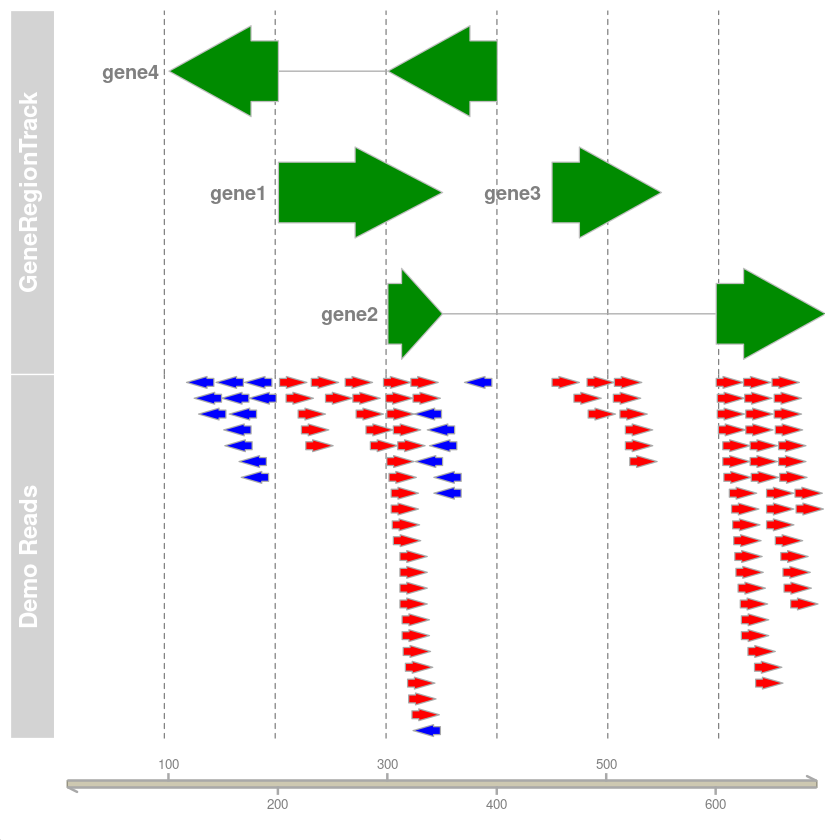

```python
source("countingModes.R")
library(Gviz)
genePlot()
```

I included **countOverlaps**, a simple function designed to identify overlapping intervals, but not really intended for alignments. As you can see, none of the modes is perfect. The major problem is that there is no possible way to resolve all of the reads that overlap genes 1 and 2.

## Processing BAM Files with summarizeOverlaps

We are now ready to determine the number of reads that overlap with each gene to produce something commonly called a gene count matrix. We are going to set the MulticoreParameter again.

### Multicore Parameters

```python
%use r
library(BiocParallel)
library(parallel)
detectCores()
bpparam <- MulticoreParam(workers=20, tasks=0)
register(bpparam)
registered()
```

128

```
$MulticoreParam
class: MulticoreParam
  bpisup: FALSE; bpnworkers: 20; bptasks: 0; bpjobname: BPJOB
  bplog: FALSE; bpthreshold: INFO; bpstopOnError: TRUE
  bpRNGseed: ; bptimeout: 2592000; bpprogressbar: FALSE
  bpexportglobals: TRUE
  bplogdir: NA
  bpresultdir: NA
  cluster type: FORK

$SnowParam
class: SnowParam
  bpisup: FALSE; bpnworkers: 124; bptasks: 0; bpjobname: BPJOB
  bplog: FALSE; bpthreshold: INFO; bpstopOnError: TRUE
  bpRNGseed: ; bptimeout: 2592000; bpprogressbar: FALSE
  bpexportglobals: TRUE
  bplogdir: NA
  bpresultdir: NA
  cluster type: SOCK

$SerialParam
class: SerialParam
  bpisup: FALSE; bpnworkers: 1; bptasks: 0; bpjobname: BPJOB
  bplog: FALSE; bpthreshold: INFO; bpstopOnError: TRUE
  bpRNGseed: ; bptimeout: 2592000; bpprogressbar: FALSE
  bpexportglobals: TRUE
  bplogdir: NA
  bpresultdir: NA
```

### Load the BAM files

Similar as Chapter 4, we first need to locate the BAM files to be used for generating the count matrix.

```python
%use r
bam_dir <- "/anvil/projects/x-tra220018/current/datasets/bulk_RNAseq/GSE80609/STARalign"
bam_files <- list.files(bam_dir, pattern="_Aligned.sortedByCoord.out.bam$", full.names=TRUE)
bam_files
```

1. '/anvil/projects/x-tra220018/current/datasets/bulk_RNAseq/GSE80609/STARalign/SRR3437043_Aligned.sortedByCoord.out.bam'

2. '/anvil/projects/x-tra220018/current/datasets/bulk_RNAseq/GSE80609/STARalign/SRR3437044_Aligned.sortedByCoord.out.bam'

3. '/anvil/projects/x-tra220018/current/datasets/bulk_RNAseq/GSE80609/STARalign/SRR3437051_Aligned.sortedByCoord.out.bam'

4. '/anvil/projects/x-tra220018/current/datasets/bulk_RNAseq/GSE80609/STARalign/SRR3437052_Aligned.sortedByCoord.out.bam'

5. '/anvil/projects/x-tra220018/current/datasets/bulk_RNAseq/GSE80609/STARalign/SRR3437053_Aligned.sortedByCoord.out.bam'

6. '/anvil/projects/x-tra220018/current/datasets/bulk_RNAseq/GSE80609/STARalign/SRR3437054_Aligned.sortedByCoord.out.bam'

7. '/anvil/projects/x-tra220018/current/datasets/bulk_RNAseq/GSE80609/STARalign/SRR3437056_Aligned.sortedByCoord.out.bam'

8. '/anvil/projects/x-tra220018/current/datasets/bulk_RNAseq/GSE80609/STARalign/SRR3437060_Aligned.sortedByCoord.out.bam'

### Load the Annotation Object

We can load the annotation object that we created above (it is OK to load it again even if you still have it in memory).

```python
load("data/GenesByExons.RData")
```

### Summarize Overlaps

Now, we have the parameters to use with **summarizeOverlaps**. By default, this function counts in single-end mode. It does have a paired-end mode that will not count both reads from a single alignment, but the documentation for that method is not very clear.

**NOTE:** The code below can produce multiple Interrupted system call errors. This is ordinarily a cause for concern. However, I confirmed that the same count matrix was produced each time. This appears to be an issue peculiar to Jupyter Notebooks, because I do not get these errors if I run the same code from a .R file in RStudio. So I suppressed all these warnings with `suppressWarnings` function.

**The cell below takes around 5 minutes to complete. We will load the output `my_se.RData` directly in next cell.**

```python
my_se <- suppressWarnings(summarizeOverlaps(features=genesByExon_gr, reads=bam_files, mode="IntersectionNotEmpty", singleEnd=FALSE,
                           fragments=FALSE, ignore.strand=FALSE, preprocess.reads=invertStrand))
save(my_se,file="my_se.RData")
```

The result is a **RangedSummarizedExperiment** object.

```python
load("my_se.RData")
my_se
```

```
class: RangedSummarizedExperiment
dim: 39629 8
metadata(0):
assays(1): counts
rownames(39629): 5S_rRNA 5_8S_rRNA ... mirbase snoZ196
rowData names(0):
colnames(8): SRR3437043_Aligned.sortedByCoord.out.bam
  SRR3437044_Aligned.sortedByCoord.out.bam ...
  SRR3437056_Aligned.sortedByCoord.out.bam
  SRR3437060_Aligned.sortedByCoord.out.bam
colData names(0):
```

The raw counts are stored in a **matrix** with gene IDs and rownames and BAM file names as column headers.

```python
head(assays(my_se)$counts)
```

A matrix: 6 × 8 of type int

|  | SRR3437043_Aligned.sortedByCoord.out.bam | SRR3437044_Aligned.sortedByCoord.out.bam | SRR3437051_Aligned.sortedByCoord.out.bam | SRR3437052_Aligned.sortedByCoord.out.bam | SRR3437053_Aligned.sortedByCoord.out.bam | SRR3437054_Aligned.sortedByCoord.out.bam | SRR3437056_Aligned.sortedByCoord.out.bam | SRR3437060_Aligned.sortedByCoord.out.bam |
| --- | --- | --- | --- | --- | --- | --- | --- | --- |
| 5S_rRNA | 0 | 0 | 0 | 1 | 0 | 0 | 0 | 0 |
| 5_8S_rRNA | 118 | 104 | 95 | 496 | 471 | 341 | 1952 | 613 |
| 7SK | 3 | 5 | 0 | 0 | 7 | 1 | 15 | 2 |
| A1BG | 9 | 7 | 0 | 0 | 1 | 4 | 0 | 2 |
| A1BG-AS1 | 22 | 13 | 7 | 3 | 13 | 14 | 11 | 16 |
| A1CF | 0 | 0 | 0 | 0 | 0 | 2 | 0 | 0 |

```python
tail(assays(my_se)$counts)
```

A matrix: 6 × 8 of type int

|  | SRR3437043_Aligned.sortedByCoord.out.bam | SRR3437044_Aligned.sortedByCoord.out.bam | SRR3437051_Aligned.sortedByCoord.out.bam | SRR3437052_Aligned.sortedByCoord.out.bam | SRR3437053_Aligned.sortedByCoord.out.bam | SRR3437054_Aligned.sortedByCoord.out.bam | SRR3437056_Aligned.sortedByCoord.out.bam | SRR3437060_Aligned.sortedByCoord.out.bam |
| --- | --- | --- | --- | --- | --- | --- | --- | --- |
| havana | 98209 | 91424 | 76479 | 89276 | 92192 | 109766 | 157320 | 74319 |
| havana_tagene | 4775 | 4514 | 4764 | 5591 | 4581 | 7189 | 6482 | 4756 |
| hsa-mir-1253 | 0 | 0 | 0 | 0 | 0 | 0 | 0 | 0 |
| hsa-mir-423 | 2 | 0 | 0 | 0 | 0 | 1 | 0 | 0 |
| mirbase | 163 | 151 | 44 | 111 | 396 | 180 | 465 | 46 |
| snoZ196 | 0 | 0 | 1 | 0 | 0 | 0 | 0 | 0 |

We can save the data two ways. First, we can save the object **my_se** as RData. This would be useful if you decided to analyze this data with **DEseq2**, a popular **Bioconductor** package for RNA-seq analysis. Second, we can save only the gene count matrix as a tab-delimited plain text file. We will use this with **edgeR**.

```python
save(my_se, file="./data/GSE80609_SE.RData")
write.table(assays(my_se)$counts, file="./data/rna_count_matrix.txt", sep="\t", quote=FALSE)
```

## Generating count matrix using HTSeq

Alternatively, if you are not familiar with handling annotations in R, there are command line tools to generate count matrix in one line using BAM files and annotation files as input. [**HTSeq**](https://htseq.readthedocs.io/en/release_0.11.1/count.html) and [**featureCount**](https://subread.sourceforge.net/featureCounts.html) are two most popular tools. Here we will show you an example of generating count matrix using HTSeq, which is already installed on our server and has similar settings as above R codes.

**Usage of HTSeq:** `htseq-count [options] <alignment_files> <gtf_file>`

**Explaination of commands:**

- **positional arguments:**

  **`alignment_files`**: Path to the SAM/BAM files containing the mapped reads. If '-' is selected, read from standard input

  **`gtf_file`**: Path to the GTF file containing the features
- **Options:**

  **`-f {sam,bam,auto}`**: Type of data. DEPRECATED: file format is detected automatically. This option is ignored.

  **`-r {pos,name}`**: 'pos' or 'name'. Sorting order of (default: name).

  **`-t FEATURE_TYPE`**: Feature type (3rd column in GTF file) to be used, all features of other type are ignored (default, suitable for Ensembl GTF files: exon)

  **`-i IDATTR`**: GTF attribute to be used as feature ID (default, suitable for Ensembl GTF files: gene_id). All feature of the right type (see -t option) within the same GTF attribute will be added together. The typical way of using this option is to count all exonic reads from each gene and add the exons but other uses are possible as well. You can call this option multiple times: in that case, the combination of all attributes separated by colons (:) will be used as a unique identifier, e.g. for exons you might use -i gene_id -i exon_number.

  **`--additional-attr`**: Additional feature attributes (default: none, suitable for Ensembl GTF files: gene_name). Use multiple times for more than one additional attribute. These attributes are only used as annotations in the output, while the determination of how the counts are added together is done based on option -i.

  **`-s {yes,no,reverse}`**: Whether the data is from a strand-specific assay. Specify 'yes', 'no', or 'reverse' (default: yes).'reverse' means 'yes' with reversed strand interpretation

  **`-m {union,intersection-strict,intersection-nonempty}`**: Mode to handle reads overlapping more than one feature (choices: union, intersection-strict, intersection-nonempty; default: union)

  **`-c OUTPUT_FILENAME`**: Filename to output the counts to instead of stdout.

  **`-n NPROCESSES`**: Number of parallel CPU processes to use (default: 1).

  **`--with-header`**: Whether to add a column header to the output TSV file indicating which column corresponds to which input BAM file. Only used if output to console or tsv or csv file. Default to False.

**NOTE: The following codes just show you an example of count matrix generation using HTSeq. They are commented out here.**

```python
%use bash
# module load biocontainers
# module load htseq/2.0.2

# check help document
# htseq-count --help
# htseq-count -f bam -r pos -t exon -s reverse -i gene_id --additional-attr gene_name \
#            -n 20 -m intersection-nonempty --with-header \
#            /anvil/projects/x-tra220018/current/datasets/bulk_RNAseq/GSE80609/STARalign/*_Aligned.sortedByCoord.out.bam \
#            /anvil/projects/x-tra220018/ref_files/Homo_sapiens.GRCh38.105.exon.gtf > ./data/rna_count_matrix_htseq.txt
```

We are now ready for next notebook that covers differential gene expression analysis with edgeR.